# Statistics

Aaron C Cochran & Emilie Henderson

April 23, 2018

# Intro

This series of exercises is intended to introduce you to basic statistical operations in R. We’ll touch on descriptive statistics, linear models, and get a quick tour of the `zeligverse` collection of packages by Gary King. The `zeligverse` collection is the de facto stats package for social scientists, and aims to improve on some of the base R quirks. Where applicable, I’ll try to include the base-R equivalent functions so you learn them as well.

```r
library(tidyverse)
library(zeligverse)
```

# Load data

The `swiss` dataset contains data on fertility and socioeconomic factors in Switzerland’s 47 French-speaking provinces in 1888 (Mosteller and Tukey, 1977, 549-551).

```r
data(swiss)
str(swiss)
```

```
## 'data.frame':    47 obs. of  6 variables:
##  $ Fertility       : num  80.2 83.1 92.5 85.8 76.9 76.1 83.8 92.4 82.4 82.9 ...
##  $ Agriculture     : num  17 45.1 39.7 36.5 43.5 35.3 70.2 67.8 53.3 45.2 ...
##  $ Examination     : int  15 6 5 12 17 9 16 14 12 16 ...
##  $ Education       : int  12 9 5 7 15 7 7 8 7 13 ...
##  $ Catholic        : num  9.96 84.84 93.4 33.77 5.16 ...
##  $ Infant.Mortality: num  22.2 22.2 20.2 20.3 20.6 26.6 23.6 24.9 21 24.4 ...
```

[,1] Fertility Ig, ‘common standardized fertility measure’ [,2] Agriculture % of males involved in agriculture as occupation [,3] Examination % draftees receiving highest mark on army examination [,4] Education % education beyond primary school for draftees. [,5] Catholic % ‘catholic’ (as opposed to ‘protestant’). [,6] Infant.Mortality live births who live less than 1 year. All variables but ‘Fertility’ give proportions of the population.

# Descriptive stats

```r
mean(swiss$Fertility)
```

```
## [1] 70.14255
```

```r
sd(swiss$Fertility)
```

```
## [1] 12.4917
```

```r
max(swiss$Fertility)
```

```
## [1] 92.5
```

```r
summary(swiss$Education)
```

```
##    Min. 1st Qu.  Median    Mean 3rd Qu.    Max.
##    1.00    6.00    8.00   10.98   12.00   53.00
```

## A slightly better description

`Hmisc` is a large package of useful r functions and contains a better descriptive summary than base R, I think. One thing to note, though, is `Hmisc` and `dplyr` have some conflicting function names (particularly, `summarize`). You want to call the package explicitly to be sure you know what you are calling. For example, `dplyr::summarize` instead of just `summarize`.

```r
library(Hmisc)
Hmisc::describe(swiss)
```

```
## swiss
##
##  6  Variables      47  Observations
## ---------------------------------------------------------------------------
## Fertility
##        n  missing distinct     Info     Mean      Gmd      .05      .10
##       47        0       46        1    70.14       14    47.58    56.24
##      .25      .50      .75      .90      .95
##    64.70    70.40    78.45    84.60    90.67
##
## lowest : 35.0 42.8 44.7 54.3 55.7, highest: 85.8 87.1 92.2 92.4 92.5
## ---------------------------------------------------------------------------
## Agriculture
##        n  missing distinct     Info     Mean      Gmd      .05      .10
##       47        0       47        1    50.66    26.15    15.65    17.36
##      .25      .50      .75      .90      .95
##    35.90    54.10    67.65    76.82    84.81
##
## lowest :  1.2  7.7 15.2 16.7 17.0, highest: 78.2 84.6 84.9 85.9 89.7
## ---------------------------------------------------------------------------
## Examination
##        n  missing distinct     Info     Mean      Gmd      .05      .10
##       47        0       22    0.996    16.49    9.006      5.0      6.0
##      .25      .50      .75      .90      .95
##     12.0     16.0     22.0     26.0     30.4
##
## lowest :  3  5  6  7  9, highest: 26 29 31 35 37
## ---------------------------------------------------------------------------
## Education
##        n  missing distinct     Info     Mean      Gmd      .05      .10
##       47        0       19    0.993    10.98    9.049      2.0      3.0
##      .25      .50      .75      .90      .95
##      6.0      8.0     12.0     23.2     29.0
##
## Value          1     2     3     5     6     7     8     9    10    11
## Frequency      1     3     4     2     4     7     4     3     2     1
## Proportion 0.021 0.064 0.085 0.043 0.085 0.149 0.085 0.064 0.043 0.021
##
## Value         12    13    15    19    20    28    29    32    53
## Frequency      5     3     1     1     1     1     2     1     1
## Proportion 0.106 0.064 0.021 0.021 0.021 0.021 0.043 0.021 0.021
## ---------------------------------------------------------------------------
## Catholic
##        n  missing distinct     Info     Mean      Gmd      .05      .10
##       47        0       46        1    41.14    44.68    2.448    2.832
##      .25      .50      .75      .90      .95
##    5.195   15.140   93.125   99.000   99.614
##
## lowest :   2.15   2.27   2.40   2.56   2.82, highest:  99.06  99.46  99.68  99.71 100.00
## ---------------------------------------------------------------------------
## Infant.Mortality
##        n  missing distinct     Info     Mean      Gmd      .05      .10
##       47        0       37    0.999    19.94    3.232    15.60    16.42
##      .25      .50      .75      .90      .95
##    18.15    20.00    21.70    23.68    24.47
##
## lowest : 10.8 15.1 15.3 16.3 16.5, highest: 23.8 24.4 24.5 24.9 26.6
## ---------------------------------------------------------------------------
```

```r
detach("package:Hmisc", unload=TRUE) # unload the package afterward
```

# Hypothesis testing

Student’s t-Test is called with `t.test()` and the mean specified as `mu`.

```r
t.test(swiss$Fertility, mu=60)
```

```
##
##  One Sample t-test
##
## data:  swiss$Fertility
## t = 5.5664, df = 46, p-value = 1.286e-06
## alternative hypothesis: true mean is not equal to 60
## 95 percent confidence interval:
##  66.47485 73.81025
## sample estimates:
## mean of x
##  70.14255
```

# Linear modeling

Building a linear model in baseR R is fairly straightforward via the `lm` model.

```r
#base R way
fit1 <- lm(Fertility ~ Education, data = swiss)
summary(fit1)
```

```
##
## Call:
## lm(formula = Fertility ~ Education, data = swiss)
##
## Residuals:
##     Min      1Q  Median      3Q     Max
## -17.036  -6.711  -1.011   9.526  19.689
##
## Coefficients:
##             Estimate Std. Error t value Pr(>|t|)
## (Intercept)  79.6101     2.1041  37.836  < 2e-16 ***
## Education    -0.8624     0.1448  -5.954 3.66e-07 ***
## ---
## Signif. codes:  0 '***' 0.001 '**' 0.01 '*' 0.05 '.' 0.1 ' ' 1
##
## Residual standard error: 9.446 on 45 degrees of freedom
## Multiple R-squared:  0.4406, Adjusted R-squared:  0.4282
## F-statistic: 35.45 on 1 and 45 DF,  p-value: 3.659e-07
```

R’s `plot.lm` method is helpful for evaluating whether the data distributions fit the assumptions inherent to the statistical test.

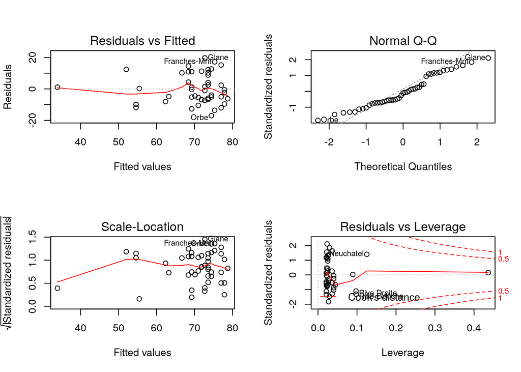

```r
par(mfrow =c(2,2))
plot(fit1)
```

Models can be compared by the `anova` function.

```r
fit2 <- lm(Fertility ~ Education + Catholic, data = swiss)
anova(fit1,fit2)
```

```
## Analysis of Variance Table
##
## Model 1: Fertility ~ Education
## Model 2: Fertility ~ Education + Catholic
##   Res.Df    RSS Df Sum of Sq      F    Pr(>F)
## 1     45 4015.2
## 2     44 3054.2  1    961.07 13.846 0.0005598 ***
## ---
## Signif. codes:  0 '***' 0.001 '**' 0.01 '*' 0.05 '.' 0.1 ' ' 1
```

Stepwise selection for linear models can be conducted with the `step` function, which chooses a model based on Akaike’s Informatin Criteria (AIC).

```r
fit3<-lm(Fertility~.,data = swiss)
fit4<-step(fit3)
```

```
## Start:  AIC=190.69
## Fertility ~ Agriculture + Examination + Education + Catholic +
##     Infant.Mortality
##
##                    Df Sum of Sq    RSS    AIC
## - Examination       1     53.03 2158.1 189.86
## <none>                          2105.0 190.69
## - Agriculture       1    307.72 2412.8 195.10
## - Infant.Mortality  1    408.75 2513.8 197.03
## - Catholic          1    447.71 2552.8 197.75
## - Education         1   1162.56 3267.6 209.36
##
## Step:  AIC=189.86
## Fertility ~ Agriculture + Education + Catholic + Infant.Mortality
##
##                    Df Sum of Sq    RSS    AIC
## <none>                          2158.1 189.86
## - Agriculture       1    264.18 2422.2 193.29
## - Infant.Mortality  1    409.81 2567.9 196.03
## - Catholic          1    956.57 3114.6 205.10
## - Education         1   2249.97 4408.0 221.43
```

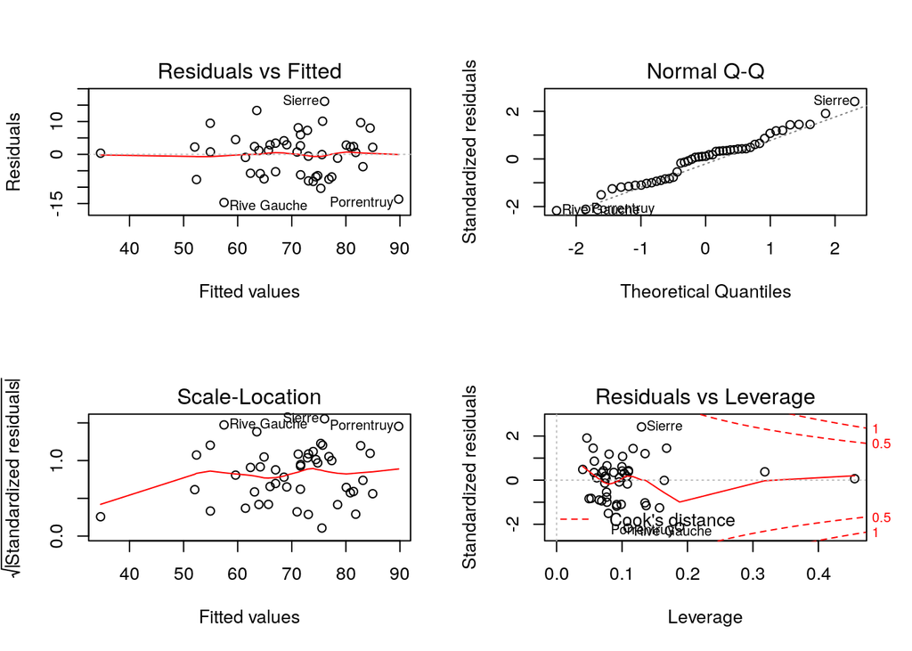

```r
par(mfrow =c(2,2))
plot(fit4)
```

```r
par(mfrow =c(1,1))
```

Many models can be compared simultaneously with `anova`.

```r
anova(fit3,fit4,fit2,fit1)
```

```
## Analysis of Variance Table
##
## Model 1: Fertility ~ Agriculture + Examination + Education + Catholic +
##     Infant.Mortality
## Model 2: Fertility ~ Agriculture + Education + Catholic + Infant.Mortality
## Model 3: Fertility ~ Education + Catholic
## Model 4: Fertility ~ Education
##   Res.Df    RSS Df Sum of Sq       F    Pr(>F)
## 1     41 2105.0
## 2     42 2158.1 -1    -53.03  1.0328 0.3154617
## 3     44 3054.2 -2   -896.10  8.7267 0.0006958 ***
## 4     45 4015.2 -1   -961.07 18.7187 9.478e-05 ***
## ---
## Signif. codes:  0 '***' 0.001 '**' 0.01 '*' 0.05 '.' 0.1 ' ' 1
```

We can see that the residual sums of squares for our `fit3` and `fit4` models are very similar, while the first two models that we made do not fit the `Fertility` response variable as closely.

# Zelig Project

Using the `zeligverse` packages that collectively are referred to as the Zelig Project, we can accomplish much of what is in base R stats with some extra quality of life improvements. From the Zelig Project documentation:

> Zelig adds considerable infrastructure to improve the use of existing methods. It translates hard-to-interpret coefficients into meaningful quantities of interest, along with the uncertainty estimates (generalizing Clarify for Stata); automates graphics and numerical summaries for all models.

> Zelig can also evaluate counterfactuals (via WhatIf); combine multiply imputed data sets to impute missing data and correct for measurement error (via Amelia and other multiple imputation functions); automates bootstrapping for all models; allows for matching for causal inference to reduce model dependence (via MatchIt and cem); and generates replication data files (for Dataverse to satisfy community replication standards).

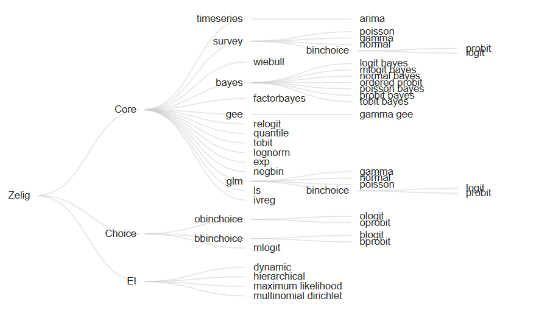

This image illustrates all of the models available in the package(s).

```r
z5_1 <- zelig(Fertility ~ Education, model = "ls", data = swiss, cite = FALSE) # cite=FALSE will keep the citation reminder suppressed
summary(z5_1)
```

```
## Model:
##
## Call:
## z5$zelig(formula = Fertility ~ Education, data = swiss)
##
## Residuals:
##     Min      1Q  Median      3Q     Max
## -17.036  -6.711  -1.011   9.526  19.689
##
## Coefficients:
##             Estimate Std. Error t value Pr(>|t|)
## (Intercept)  79.6101     2.1041  37.836  < 2e-16
## Education    -0.8624     0.1448  -5.954 3.66e-07
##
## Residual standard error: 9.446 on 45 degrees of freedom
## Multiple R-squared:  0.4406, Adjusted R-squared:  0.4282
## F-statistic: 35.45 on 1 and 45 DF,  p-value: 3.659e-07
##
## Next step: Use 'setx' method
```

The `-0.86` coefficient suggests there is a large negative effect on Fertility with increasing Education. Let’s explore those differences further using `setx()` and `setx1()`. This will allow us to simulate differing proportions of the educated population.

```r
# set education to 5 and 15
z5_1 <- setx(z5_1, Education = 5)
z5_1 <- setx1(z5_1, Education = 15)

z5_1 <- sim(z5_1)
```

Plot the differences from our simulated Education levels.

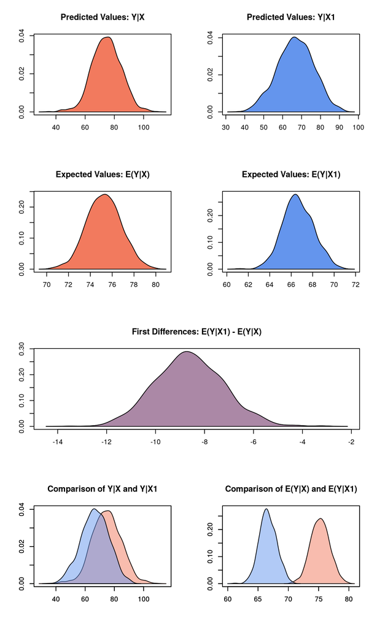

```r
plot(z5_1)
```

We can also do this for a range of values

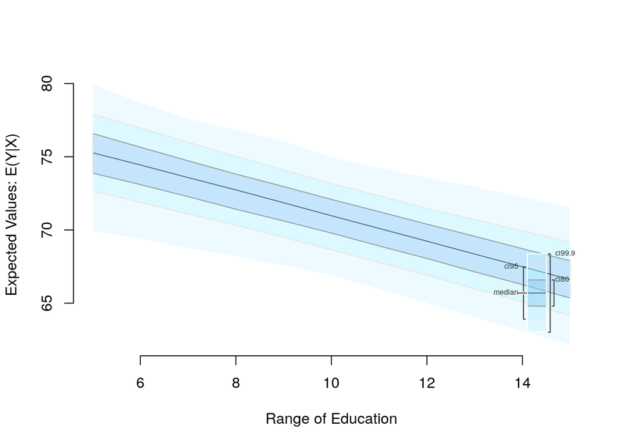

```r
z5_2 <- zelig(Fertility ~ Education, model = "ls", data = swiss, cite = FALSE)

# set Education to range from 5 to 15 at single integer increments
z5_2 <- setx(z5_2, Education = 5:15)

# run simulations and estimate quantities of interest
z5_2 <- sim(z5_2)
# Then use the plot() function as before:

z5_2 <- plot(z5_2)
```

### `Zelig` the `tidyverse` way

`zelig` works with `tidyverse` nicely as well. We can incorporate `zelig()` models into our workflow unlike the base R models.

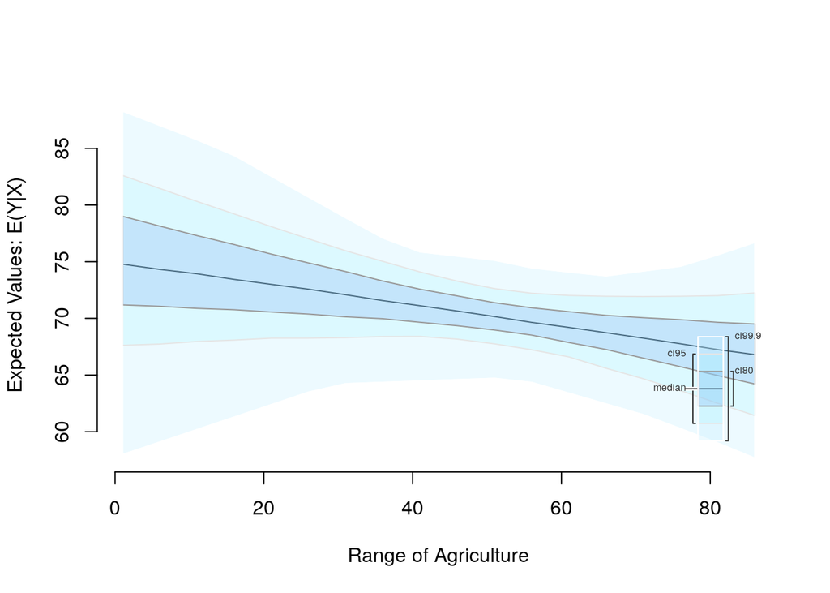

```r
swiss %>%
    zelig(Fertility ~ Agriculture + Examination, model = 'ls', data = .,
          cite = FALSE) %>%
    setx(Agriculture = seq(1, 90, by = 5)) %>%
    sim() %>%
    plot()
```

You can even get first differences in the same workflow.

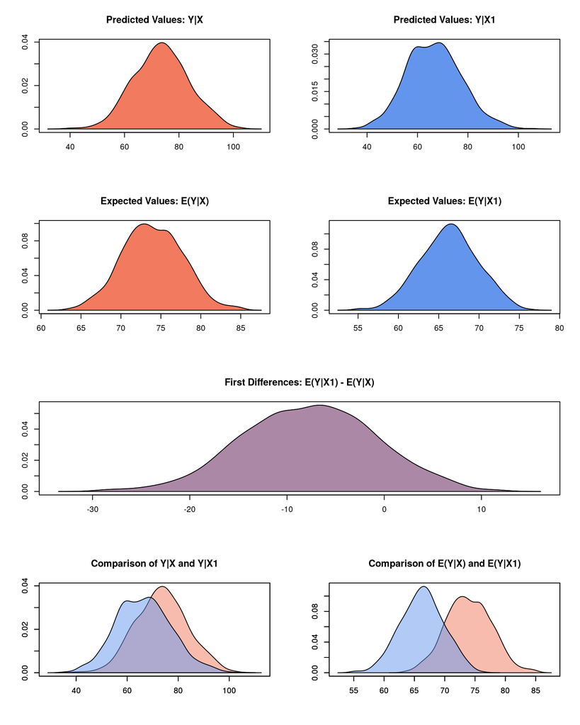

```r
swiss %>%
    zelig(Fertility ~ Agriculture + Examination, model = 'ls', data = .,
          cite = FALSE) %>%
    setx(Agriculture = 10) %>%
    setx1(Agriculture = 90) %>%
    sim() %>%
    plot()
```